# PET/CT-PSMA, Mateos Bogoni

Análise: [Henrique Laureano](https://henriquelaureano.github.io/)

Last modification on* 2021-08-11 11:14:34

# Dados demográficos e variáveis clínicas

[figure not shown]

[figure not shown]

# Variáveis contínuas e discretas

> Se a linha estiver em vermelho, p-valor < 0.05. Ou seja, diferença significativa

Teste de normalidade, hipótese nula: normalidade

| Variable | Mean | SD | Statistic value | p-value | Test |
| --- | --- | --- | --- | --- | --- |
| Age | 65.898305 | 7.680461 | 0.9832616 | 0.59188632 | Shapiro-Wilk normality test |
| InitialPSABeforeTh | 14.161186 | 11.287611 | 0.8106218 | 0.00000030 | Shapiro-Wilk normality test |
| PSAatPET | 1.672881 | 1.921640 | 0.7748398 | 0.00000004 | Shapiro-Wilk normality test |
| PSAdt | 11.198305 | 8.941872 | 0.8581190 | 0.00000621 | Shapiro-Wilk normality test |

Hipótese nula: independência (não há associação significativa)

| Variable | A | B | C | D | E | F | Statistic value | p-value | Test |
| --- | --- | --- | --- | --- | --- | --- | --- | --- | --- |
| Nível de PSA sérico próximo ao exame | 2 | 23 | 5 | 12 | 9 | 8 | 27.13559 | 5.4e-05 | Chi-square test |

Hipótese nula: independência (não há associação significativa)

| Variable | A | B | Statistic value | p-value | Test |
| --- | --- | --- | --- | --- | --- |
| Tempo de duplicação do PSA (=< e >10 meses) | 33 | 26 | 0.831 | 0.362 | Chi-square test |

Hipótese nula: independência (não há associação significativa)

| Variable | A | B | C | D | Statistic value | p-value | Test |
| --- | --- | --- | --- | --- | --- | --- | --- |
| Gleason score | 39 | 10 | 9 | 1 | 56.45763 | 3e-12 | Chi-square test |

Hipótese nula: independência (não há associação significativa)

| Variable | A | B | Statistic value | p-value | Test |
| --- | --- | --- | --- | --- | --- |
| PET | 21 | 38 | 4.898 | 0.027 | Chi-square test |

| TTO PRE PSMA | TTO POS PSMA | n |
| --- | --- | --- |
| ADT | Abi/Enza | 6 |
| ADT | ADT | 3 |
| ADT | Bilateral Orchiectomy | 1 |
| ADT | Rt+ADT | 2 |
| Bilateral Orchiectomy | ADT | 1 |
| Chemotx | Abi/Enza | 1 |
| Radiotherapy only | Abi/Enza | 2 |
| Radiotherapy only | ADT | 4 |
| Radiotherapy only | Chemotx | 2 |
| Radiotherapy only | Radiotherapy only | 13 |
| Radiotherapy only | Rt+ADT | 4 |
| Radiotherapy only | Surveillance | 4 |
| Rt+ADT | Abi/Enza | 2 |
| Rt+ADT | ADT | 1 |
| Rt+ADT | Rt+ADT | 7 |
| Rt+ADT | Surveillance | 1 |
| Salvage PTR | ADT | 1 |
| Salvage PTR | Rt+ADT | 1 |
| SalvageLymphadenectomy | Abi/Enza | 2 |
| SalvageLymphadenectomy | Bilateral Orchiectomy | 1 |

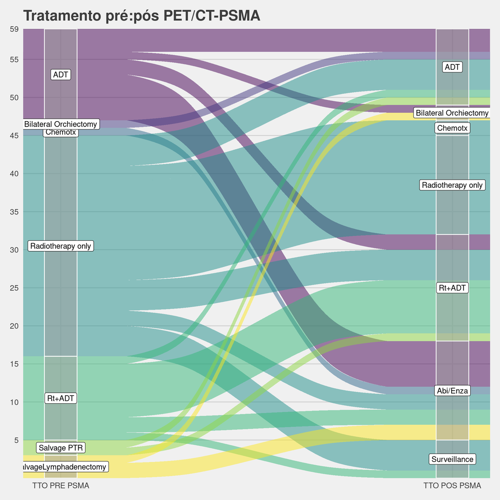

# PET/CT-PSMA

Welch two sample t-test, alternative hypothesis: two-sided

| By | PET 0 mean (n=21) | PET 1 mean (n=38) | Difference | Conf.low | Conf.high | Statistic value | p-value |
| --- | --- | --- | --- | --- | --- | --- | --- |
| Age | 63.9524 | 66.9737 | -3.0213 | -7.7092 | 1.6666 | -1.3150 | 0.1983 |
| PSAatPET | 0.8667 | 2.1184 | -1.2518 | -2.0655 | -0.4381 | -3.0842 | 0.0032 |
| PSAdt | 7.0190 | 13.5079 | -6.4888 | -10.2926 | -2.6851 | -3.4176 | 0.0012 |
| InitialPSA | 11.5571 | 15.6003 | -4.0431 | -9.6366 | 1.5504 | -1.4501 | 0.1530 |
| Gleason | 7.3333 | 7.6316 | -0.2982 | -0.7053 | 0.1088 | -1.4703 | 0.1475 |

| TNM | PET 0 | PET 1 | Total | Rate | Statistic value | p-value | Test |
| --- | --- | --- | --- | --- | --- | --- | --- |
| T2 | 12 | 10 | 22 | 0.455 | 0.364 | 0.546 | Chi-square test |
| T3 | 9 | 13 | 22 | 0.591 | 0.364 | 0.546 | Chi-square test |

| Variable | PET 0 | PET 1 | Total | Statistic value | p-value | Test |
| --- | --- | --- | --- | --- | --- | --- |
| RT como 1o tratamento | 16 | 13 | 29 | 0.31 | 0.577 | Chi-square test |

# Regressão logística

> Starting with four characteristics: `PSAatPET`, `PSAdt`, `Gleason` and `RT1oTTO` (RT as first treament, yes or no).

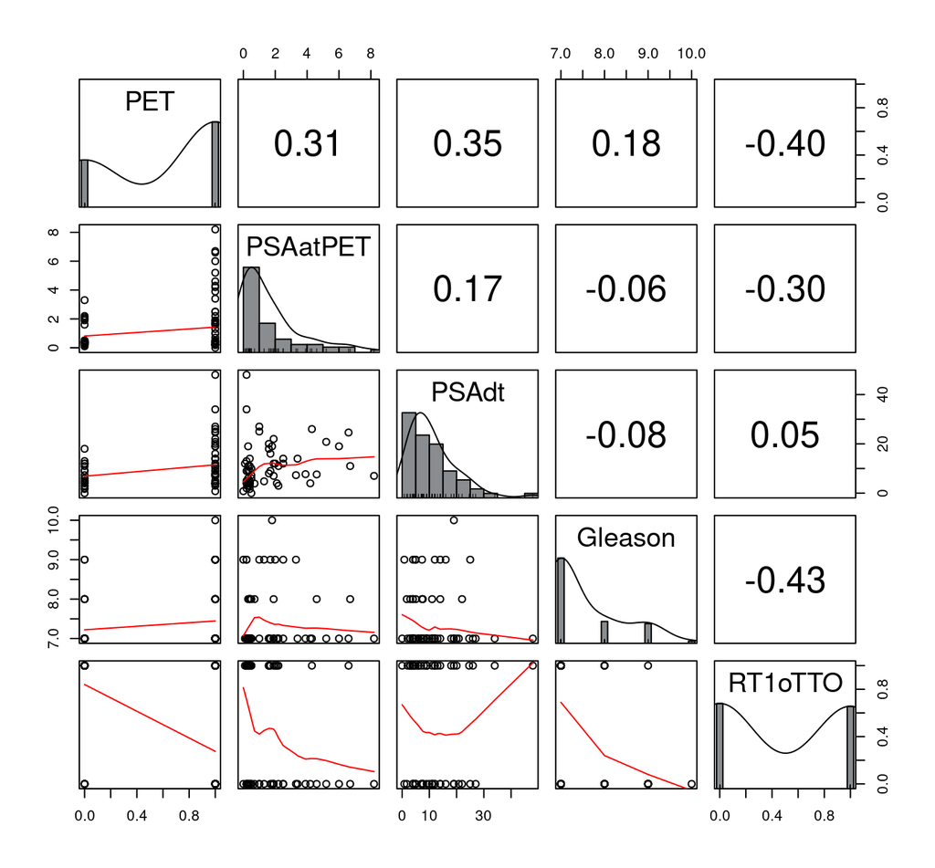

> However, we work with those variables categorized.

```
 PET         PSAatPET         PSAdt    Gleason RT1oTTO
 0:21   [0,0.2)  : 2   =<10 meses:33   7 :39   0:30
 1:38   [0.2,0.5):23   >10 meses :26   8 :10   1:29
        [0.5,1)  : 5                   9 : 9
        [1,2)    :12                   10: 1
        [2,4)    : 9
        [4,10]   : 8
```

> Performing variable selection through the AIC (Akaike information criterion) measure, we see that `PSAatPET` and `Gleason` are not statistically significant when the goal is to explain the variability of PET/CT-PSMA.

| term | estimate | std.error | statistic | p.value |
| --- | --- | --- | --- | --- |
| (Intercept) | 1.1923 | 0.5318 | 2.2419 | 0.0250 |
| PSAdt>10 meses | 1.1089 | 0.6379 | 1.7383 | 0.0822 |
| RT1oTTO | -1.8698 | 0.6382 | -2.9301 | 0.0034 |

> The intercept is the reference level. Here, `PSAdt=<10meses` and `RT1oTTO=0`.

> Before some interpretations, lets see some graphs to check the model fit quality. The residuals in its most simple idea is the diference between the observed and the expected (fitted). In `A` we should expect all std residuals to be between the (-3, 3) interval. If outside, we have evidence of outliers presence. In the other graphs, in black we show the model fit. The ideal scenario would be a steady line on zero. We have here a behavior similar to that, so our model is well fitted/adequate/suitable.

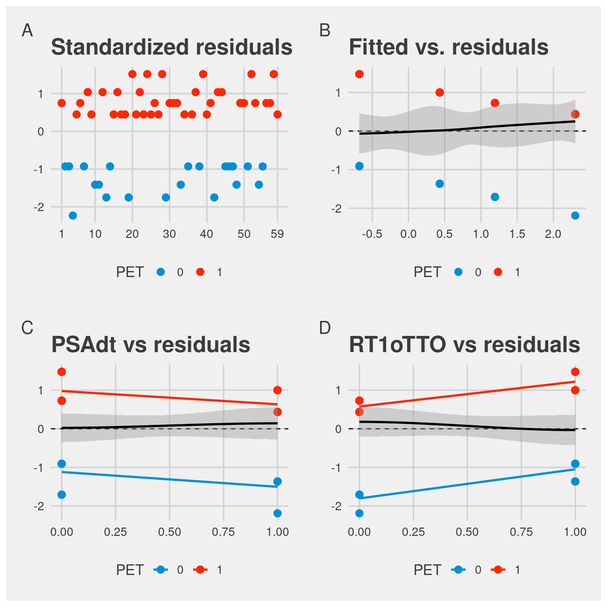

[figure not shown]

## Interpretando os coeficientes

```
   (Intercept) PSAdt>10 meses        RT1oTTO
      1.192268       1.108920      -1.869841
```

> The logistic regression return the log odds. Nevertheless, those values do not have a precise or meaningful interpretation. We can convert the default log odds into probabilities through the logistic function

> $$\text{Logistic function}(X\beta) = \frac{e^{X\beta}}{1 + e^{X\beta}}.$$

> The default probability (`PSAdt=<10meses` and `RT1oTTO=0`) of PET/CS-PSMA is

```
[1] 0.7671465
```

> Changing just the `PSAdt` to >10meses or just the `RT1oTTO` to 1, will change the probability to

```
[1] 0.9089754
```

```
[1] 0.3368033
```

> respectively.

> BY changing both the probability goes to

```
[1] 0.6061954
```

> Another possibility is looking to the odds ratios. An odds of 1 equivalent to a probability of 0.5.

> Changing just the `PSAdt` to >10meses or just the `RT1oTTO` to 1, will get odds of

```
[1] 3.031083
```

```
[1] 0.1541482
```

> By changing both the odds goes to

```
[1] 0.4672359
```

> a 53% decrease.